# Economic consequences

### 0.0.1 Document history

Orignal Publish Date: 02 September 2021

Updated on: 11:09 AM – 12 September, 2021

So far we have been focusing on the economic consequences of having political families in constituencies by comparing them against non-families. Here onwards, we will be comparing stable against non-families and other categories.

The second question is where do political families come from. This would need longitudinal data or historical data. Given the above datasets are recent we will depend on population census, economic census, weather data, agitation data, criminality data etc.

In our full dataset we have 667 winners from the stable family and 415 after the family formation. Since 2009, it is 161 . We would only be able to use these stable category to assess the consequence of family politicians after 2009 since that category is formed after 2008. This limits us to MPLADS, PMGSY and NREGA

# 1 Econ consequences

# 2 MPLADS

## 2.1 Summary

No

Variable

Stats / Values

Freqs (% of Valid)

Graph

Missing

1

constituency_no  
[integer]

Mean (sd) : 34.3 (25.5)  
min < med < max:  
1 < 25 < 80  
IQR (CV) : 43 (0.7)

72 distinct values

0  
(0.0%)

2

year  
[integer]

1 distinct value

2009 : 14709 (100.0%)

0  
(0.0%)

3

v1  
[integer]

Mean (sd) : 7354 (4246.3)  
min < med < max:  
0 < 7354 < 14708  
IQR (CV) : 7354 (0.6)

14709 distinct values  
(Integer sequence)

0  
(0.0%)

4

st_name  
[character]

1. uttar pradesh

14709 (100.0%)

0  
(0.0%)

5

lsrs  
[character]

1. LS/RS: 15th Lok Sabha

14709 (100.0%)

0  
(0.0%)

6

constituency  
[character]

1. mathura  
2. allahabad  
3. firozabad  
4. amroha  
5. muzaffarnagar  
6. saharanpur  
7. kaushambi  
8. bijnor  
9. rampur  
10. robertsganj  
[ 62 others ]

1092 ( 7.4%)  
848 ( 5.8%)  
604 ( 4.1%)  
559 ( 3.8%)  
517 ( 3.5%)  
506 ( 3.4%)  
487 ( 3.3%)  
455 ( 3.1%)  
442 ( 3.0%)  
397 ( 2.7%)  
8802 (59.8%)

0  
(0.0%)

7

mp  
[character]

1. Shri Jayant Chaudhary  
2. Kunwar Rewati Raman Sing  
3. Shri Raj Babbar  
4. Shri Devendra Nagpal  
5. Shri Kadir Rana  
6. Shri Jagdish Singh Rana  
7. Shri Shailendra Kumar  
8. Shri Sanjay Singh Chauhan  
9. Smt. Jaya Prada Nahata  
10. Shri Pakauri Lal  
[ 62 others ]

1092 ( 7.4%)  
848 ( 5.8%)  
604 ( 4.1%)  
559 ( 3.8%)  
517 ( 3.5%)  
506 ( 3.4%)  
487 ( 3.3%)  
455 ( 3.1%)  
442 ( 3.0%)  
397 ( 2.7%)  
8802 (59.8%)

0  
(0.0%)

8

nodaldistrict  
[character]

1. mathura  
2. allahabad  
3. bijnore  
4. firozabad  
5. muzaffarnagar  
6. saharanpur  
7. kaushambi  
8. rampur  
9. bareilly  
10. gorakhpur  
[ 54 others ]

1092 ( 7.4%)  
1043 ( 7.1%)  
757 ( 5.1%)  
604 ( 4.1%)  
517 ( 3.5%)  
506 ( 3.4%)  
487 ( 3.3%)  
442 ( 3.0%)  
432 ( 2.9%)  
428 ( 2.9%)  
8401 (57.1%)

0  
(0.0%)

9

allsanctionedworksiliworksnotsan  
[character]

1. All Sanctioned Works

14709 (100.0%)

0  
(0.0%)

10

worknamewithlocation  
[character]

1. ek high mask light  
2. const. of cc road in kanp  
3. five handpump  
4. balmiki basti mein ek hig  
5. const of cc road in kanpu  
6. consrt. of crematorium sh  
7. cc road in dalit basti  
8. const. of milan kendra an  
9. 8-solar light  
10. boundarywall of graveyard  
[ 14312 others ]

23 ( 0.2%)  
21 ( 0.1%)  
14 ( 0.1%)  
11 ( 0.1%)  
10 ( 0.1%)  
9 ( 0.1%)  
8 ( 0.1%)  
7 ( 0.0%)  
6 ( 0.0%)  
6 ( 0.0%)  
14594 (99.2%)

0  
(0.0%)

11

blockurban  
[character]

1. urban  
2. (Empty string)  
3. city  
4. block  
5. raya  
6. naujheel  
7. amroha  
8. mathura  
9. firozabad  
10. ghorawal  
[ 994 others ]

617 ( 4.2%)  
527 ( 3.6%)  
348 ( 2.4%)  
275 ( 1.9%)  
184 ( 1.3%)  
183 ( 1.2%)  
175 ( 1.2%)  
164 ( 1.1%)  
151 ( 1.0%)  
147 ( 1.0%)  
11938 (81.2%)

0  
(0.0%)

12

wardgrampanchayat  
[character]

1. (Empty string)  
2. gram panchayat  
3. city  
4. gram punchayat  
5. gp  
6. ward  
7. urban  
8. saharanpur  
9. nagar panchayat  
10. city gajraula  
[ 8644 others ]

1279 ( 8.7%)  
198 ( 1.3%)  
188 ( 1.3%)  
99 ( 0.7%)  
66 ( 0.4%)  
65 ( 0.4%)  
39 ( 0.3%)  
36 ( 0.2%)  
33 ( 0.2%)  
31 ( 0.2%)  
12675 (86.2%)

0  
(0.0%)

13

dateofreceiptofproposalforworkfr  
[character]

1. 22/10/2012  
2. 7/11/09  
3. 22/12/2012  
4. 5/11/12  
5. 22/09/2012  
6. 19/08/2013  
7. 26/05/2010  
8. 16/07/2012  
9. 20/10/2012  
10. 16/11/2011  
[ 1368 others ]

167 ( 1.1%)  
129 ( 0.9%)  
119 ( 0.8%)  
113 ( 0.8%)  
112 ( 0.8%)  
110 ( 0.7%)  
109 ( 0.7%)  
88 ( 0.6%)  
88 ( 0.6%)  
86 ( 0.6%)  
13588 (92.4%)

0  
(0.0%)

14

dateofsanctionofworkbydistrict  
[character]

1. 25/02/2013  
2. 30/03/2010  
3. 23/12/2011  
4. 22/12/2011  
5. 28/02/2014  
6. 30/11/2011  
7. 30/11/2009  
8. 7/11/12  
9. 19/02/2014  
10. 20/11/2013  
[ 1147 others ]

311 ( 2.1%)  
215 ( 1.5%)  
164 ( 1.1%)  
150 ( 1.0%)  
133 ( 0.9%)  
130 ( 0.9%)  
124 ( 0.8%)  
113 ( 0.8%)  
107 ( 0.7%)  
103 ( 0.7%)  
13159 (89.5%)

0  
(0.0%)

15

executingagency  
[character]

1. R.E.S.  
2. RES  
3. U.P. NEDA MATHURA  
4. MANAGER  
5. CONST.DIVN; UP JAL NIGAM  
6. SAMAJ KALYAN NIRMAN NIGAM  
7. Electric Deptt  
8. RED  
9. DUDA BIJNOR  
10. res  
[ 1301 others ]

1109 ( 7.5%)  
886 ( 6.0%)  
534 ( 3.6%)  
442 ( 3.0%)  
278 ( 1.9%)  
268 ( 1.8%)  
259 ( 1.8%)  
218 ( 1.5%)  
212 ( 1.4%)  
178 ( 1.2%)  
10325 (70.2%)

0  
(0.0%)

16

costsanctionedbydistrict  
[numeric]

Mean (sd) : 479289.5 (823240.9)  
min < med < max:  
2440 < 3e+05 < 34500000  
IQR (CV) : 453200 (1.7)

5039 distinct values

0  
(0.0%)

17

workstatus  
[character]

1. COMPLETED  
2. DISCONTINUED  
3. NOT YET STARTED  
4. ON GOING  
5. Status not reported

10018 (68.1%)  
110 ( 0.7%)  
206 ( 1.4%)  
2162 (14.7%)  
2213 (15.0%)

0  
(0.0%)

18

blockurban_missing  
[numeric]

Min : 0  
Mean : 0.1  
Max : 1

0 : 13221 (89.9%)  
1 : 1488 (10.1%)

0  
(0.0%)

19

gp_missing  
[numeric]

Min : 0  
Mean : 0.1  
Max : 1

0 : 12684 (86.2%)  
1 : 2025 (13.8%)

0  
(0.0%)

20

villageidgis  
[numeric]

Mean (sd) : 9927.5 (101866.7)  
min < med < max:  
0 < 2175 < 9070012  
IQR (CV) : 12396 (10.3)

2895 distinct values

4514  
(30.7%)

21

villagename_gis  
[character]

1. (Empty string)  
2. bairi  
3. bharwari  
4. dorahar  
5. jura  
6. jhalwa  
7. faridpur salem  
8. tilauli  
9. barouli  
10. janari  
[ 3006 others ]

4514 (30.7%)  
304 ( 2.1%)  
112 ( 0.8%)  
112 ( 0.8%)  
104 ( 0.7%)  
78 ( 0.5%)  
77 ( 0.5%)  
76 ( 0.5%)  
74 ( 0.5%)  
74 ( 0.5%)  
9184 (62.4%)

0  
(0.0%)

22

block_name  
[logical]

All NA’s

14709  
(100.0%)

23

state_ut  
[character]

1. bihar  
2. chhattisgarh  
3. delhi  
4. haryana  
5. jharkhand  
6. madhya pradesh  
7. uttar pradesh  
8. uttarakhand

1 ( 0.0%)  
2 ( 0.0%)  
9 ( 0.1%)  
3 ( 0.0%)  
1 ( 0.0%)  
24 ( 0.2%)  
14657 (99.6%)  
12 ( 0.1%)

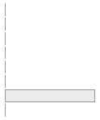

0  
(0.0%)

24

matched  
[numeric]

Min : 0  
Mean : 0.6  
Max : 1

0 : 5720 (38.9%)  
1 : 8989 (61.1%)

0  
(0.0%)

25

ac_no_gis  
[numeric]

Mean (sd) : 172.1 (137)  
min < med < max:  
1 < 128 < 403  
IQR (CV) : 270 (0.8)

359 distinct values

3027  
(20.6%)

26

ac_name_gis  
[character]

1. (Empty string)  
2. siwalkhas (sc)  
3. mant  
4. saharanpur  
5. shikohabad  
6. baldev  
7. hapur (sc)  
8. beyalsi  
9. chhata  
10. kithore  
[ 461 others ]

3027 (20.6%)  
275 ( 1.9%)  
235 ( 1.6%)  
232 ( 1.6%)  
196 ( 1.3%)  
184 ( 1.3%)  
171 ( 1.2%)  
150 ( 1.0%)  
140 ( 1.0%)  
126 ( 0.9%)  
9973 (67.8%)

0  
(0.0%)

27

elecyear_missing  
[numeric]

1 distinct value

0 : 14709 (100.0%)

0  
(0.0%)

28

ac_no_gis_post  
[numeric]

Mean (sd) : 139.9 (126.3)  
min < med < max:  
1 < 84 < 403  
IQR (CV) : 201 (0.9)

258 distinct values

8686  
(59.1%)

29

project_id  
[numeric]

Mean (sd) : 98726.8 (14345.6)  
min < med < max:  
265 < 99318 < 124341  
IQR (CV) : 21615 (0.1)

14709 distinct values

0  
(0.0%)

30

costnew  
[numeric]

Mean (sd) : 383998.9 (316550)  
min < med < max:  
2440 < 3e+05 < 1e+06  
IQR (CV) : 453200 (0.8)

3898 distinct values

0  
(0.0%)

31

percentilecost  
[character]

1. 0-25  
2. 26-50  
3. 51-75  
4. 76-100

3491 (23.7%)  
2948 (20.0%)  
3467 (23.6%)  
4803 (32.7%)

0  
(0.0%)

32

newexpend  
[character]

1. 0-2  
2. 10+  
3. 2-5  
4. 5-10

5813 (39.5%)  
1485 (10.1%)  
4617 (31.4%)  
2794 (19.0%)

0  
(0.0%)

33

newdaterec  
[IDate, Date]

min : 2001-01-28  
med : 2011-12-05  
max : 2014-12-15  
range : 13y 10m 17d

1378 distinct values

0  
(0.0%)

34

newdatesanc  
[IDate, Date]

min : 2004-10-26  
med : 2012-01-11  
max : 2015-06-29  
range : 10y 8m 3d

1157 distinct values

0  
(0.0%)

35

days  
[integer]

Mean (sd) : 67.5 (104.7)  
min < med < max:  
-1950 < 45 < 3852  
IQR (CV) : 70 (1.6)

569 distinct values

0  
(0.0%)

36

date.sancnew  
[POSIXct, POSIXt]

min : 2004-10-26  
med : 2012-03-17  
max : 2015-06-29  
range : 10y 8m 3d

1157 distinct values

0  
(0.0%)

37

date.recnew  
[POSIXct, POSIXt]

min : 2001-01-28  
med : 2011-12-02  
max : 2014-12-15  
range : 13y 10m 17d

1378 distinct values

0  
(0.0%)

38

worknew  
[character]

1. Road  
2. Transformer  
3. Class Room  
4. Handpump  
5. Khadnja  
6. Solar  
7. Construction  
8. Others  
9. Interlocking  
10. Drain  
[ 2 others ]

4107 (27.9%)  
1795 (12.2%)  
1786 (12.1%)  
1519 (10.3%)  
1133 ( 7.7%)  
1090 ( 7.4%)  
1002 ( 6.8%)  
997 ( 6.8%)  
408 ( 2.8%)  
383 ( 2.6%)  
489 ( 3.3%)

0  
(0.0%)

39

category_work  
[character]

1. Construction  
2. Education  
3. Electricity  
4. Others  
5. Road  
6. Sanitation  
7. Water

2730 (18.6%)  
1786 (12.1%)  
3187 (21.7%)  
997 ( 6.8%)  
4107 (27.9%)  
383 ( 2.6%)  
1519 (10.3%)

0  
(0.0%)

40

catfam  
[integer]

Min : 1  
Mean : 1.6  
Max : 2

1 : 6264 (42.6%)  
2 : 8445 (57.4%)

0  
(0.0%)

41

count  
[integer]

1 distinct value

1 : 14709 (100.0%)

0  
(0.0%)

42

cost_cat  
[factor]

1. Low  
2. Medium  
3. High

5813 (39.5%)  
4617 (31.4%)  
4279 (29.1%)

0  
(0.0%)

## 2.2 Top level summary: stable v/s Non-family

MPLADS 2009

| Entity | N PCs | Avg. number of projects in a PC | Avg. cost sanctioned for a project | Avg. number of days to sanction |
| --- | --- | --- | --- | --- |
| Rest | 47 | 264 | 433216 | 59 |
| Stable | 25 | 548 | 324183 | 79 |

```
## # A tibble: 72 × 3
## # Groups:   dyn_cum_2_text [2]
##    dyn_cum_2_text constituency_name mean_cost
##    <chr>          <chr>                 <dbl>
##  1 Rest           AGRA                713667.
##  2 Rest           AKBARPUR            396305.
##  3 Rest           ALIGARH             789755.
##  4 Rest           BAHRAICH            782345.
##  5 Rest           BALLIA              335066.
##  6 Rest           BANDA               425206.
##  7 Rest           BARABANKI           668063.
##  8 Rest           BAREILLY            325995.
##  9 Rest           BASTI               387763.
## 10 Rest           BHADOHI             458227.
## # … with 62 more rows
```

## 2.3 Break-up

### 2.3.1 Projects

**Question** - Is there any difference in the project choices of family politicians?

This table shows the composition of the category of the projects they choose work on.

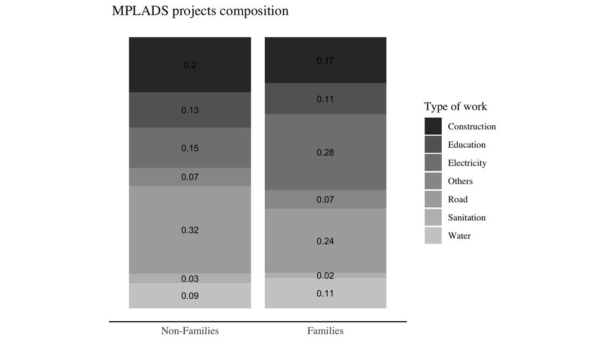

This chart shows the average number of projects of each categories according to the family type.

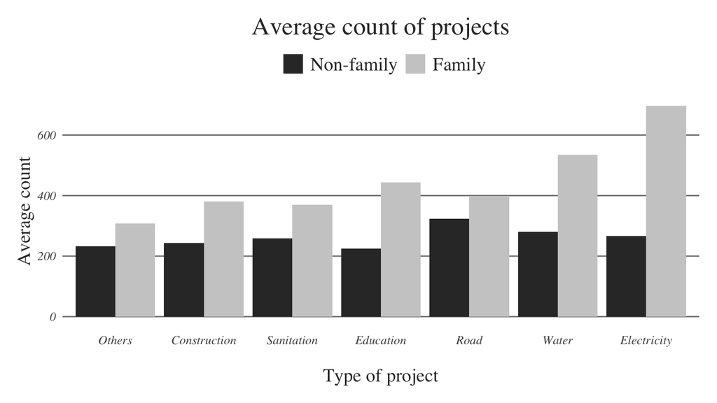

### 2.3.2 Expenditure

**Question** - Is there any difference in the spending patterns of family politicians?

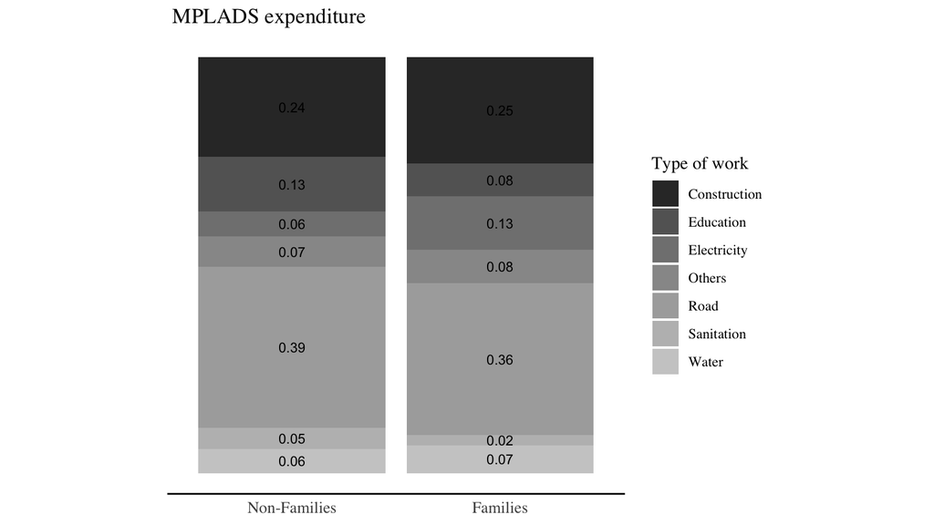

**Question** : What’s the average cost of a project for each categories?

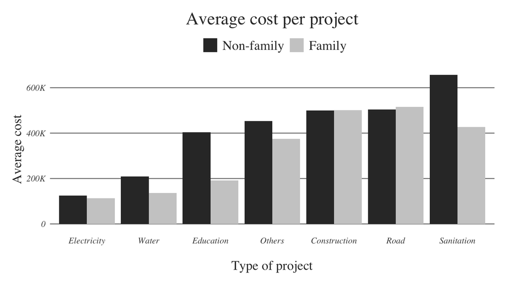

## 2.4 cost categories

We categorised the projects into three depending upon the cost of the project:

Categories:

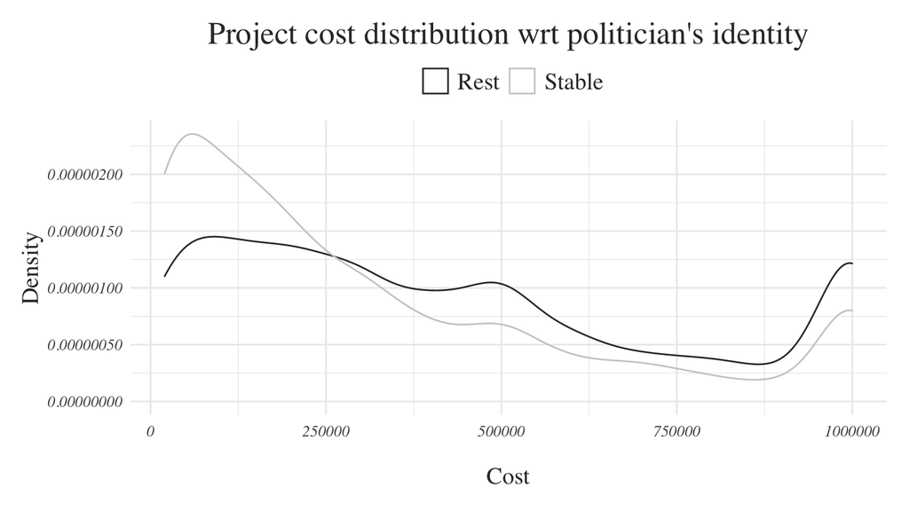

Project cost categories wrt politician’s identity

| Cost Categry | Politicians Identity | Proportion of projects |
| --- | --- | --- |
| Low | Rest | 0.32 |
| Low | Stable | 0.49 |
| Medium | Rest | 0.34 |
| Medium | Stable | 0.28 |
| High | Rest | 0.34 |
| High | Stable | 0.23 |

# 3 PMGSY

## 3.1 Summary table

No

Variable

Stats / Values

Freqs (% of Valid)

Graph

Missing

1

year  
[integer]

Min : 2004  
Mean : 2007.3  
Max : 2009

2004 : 1203 (33.1%)  
2009 : 2426 (66.9%)

0  
(0.0%)

2

sr.no.  
[numeric]

Mean (sd) : 680.1 (488.3)  
min < med < max:  
1 < 607 < 1768  
IQR (CV) : 817 (0.7)

1768 distinct values

0  
(0.0%)

3

district name  
[character]

1. Sitapur  
2. Hardoi  
3. Lakhimpur-Kherii  
4. Shahjahanpur  
5. Moradabad  
6. Rae Bareli  
7. Unnao  
8. Baghpat  
9. Bahraich  
10. Sonebhadra  
[ 65 others ]

186 ( 5.1%)  
170 ( 4.7%)  
132 ( 3.6%)  
124 ( 3.4%)  
94 ( 2.6%)  
94 ( 2.6%)  
94 ( 2.6%)  
92 ( 2.5%)  
85 ( 2.3%)  
85 ( 2.3%)  
2473 (68.1%)

0  
(0.0%)

4

programme implementation unit  
[character]

1. DPIU Of Sitapur  
2. DPIU Of Hardoi  
3. DPIU Of Lakhimpur-KheriI  
4. DPIU Of Shahjahanpur  
5. DPIU Of Moradabad  
6. DPIU Of Rae Bareli  
7. DPIU Of Unnao  
8. DPIU Of Baghpat  
9. DPIU Of Bahraich  
10. DPIU Of Sonebhadra  
[ 67 others ]

186 ( 5.1%)  
170 ( 4.7%)  
132 ( 3.6%)  
124 ( 3.4%)  
94 ( 2.6%)  
94 ( 2.6%)  
94 ( 2.6%)  
92 ( 2.5%)  
85 ( 2.3%)  
85 ( 2.3%)  
2473 (68.1%)

0  
(0.0%)

5

block name  
[character]

1. pisawan  
2. chopan  
3. binauli  
4. dingarpur  
5. pasgawan  
6. nawabganj  
7. shahbad  
8. hallia  
9. dilari  
10. jewar  
[ 695 others ]

29 ( 0.8%)  
23 ( 0.6%)  
22 ( 0.6%)  
22 ( 0.6%)  
22 ( 0.6%)  
21 ( 0.6%)  
21 ( 0.6%)  
20 ( 0.6%)  
19 ( 0.5%)  
19 ( 0.5%)  
3411 (94.0%)

0  
(0.0%)

6

package no.  
[character]

1. UP3536  
2. UP6440  
3. UP68147  
4. UP0469  
5. UP0758  
6. UP0832  
7. UP0837  
8. UP0841  
9. UP4459  
10. UP63104  
[ 2081 others ]

12 ( 0.3%)  
9 ( 0.2%)  
8 ( 0.2%)  
7 ( 0.2%)  
7 ( 0.2%)  
7 ( 0.2%)  
7 ( 0.2%)  
7 ( 0.2%)  
7 ( 0.2%)  
7 ( 0.2%)  
3551 (97.9%)

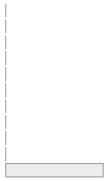

0  
(0.0%)

7

sanctioned year  
[character]

1. 2007 - 2008  
2. 2009 - 2010  
3. 2010 - 2011  
4. 2011 - 2012  
5. 2012 - 2013

1203 (33.1%)  
26 ( 0.7%)  
162 ( 4.5%)  
478 (13.2%)  
1760 (48.5%)

0  
(0.0%)

8

work type  
[character]

1. ROAD

3629 (100.0%)

0  
(0.0%)

9

road name / bridge name  
[character]

1. Koraon - Rajpur (KKD) roa  
2. Hasanpur - Atrasi Amroha  
3. Kaptanganj - Ahiraula  
4. Karwi Boodha Road - Rajap  
5. Rateora - Devghat  
6. Sitapur - Badagaon  
7. T-01 (Powayan) - Nigohi R  
8. Tilhar (T-04) - Jaitipur  
9. Akbarpur - Iltifatganj  
10. Anoopshahr - Shikarpur  
[ 3582 others ]

4 ( 0.1%)  
3 ( 0.1%)  
3 ( 0.1%)  
3 ( 0.1%)  
3 ( 0.1%)  
3 ( 0.1%)  
3 ( 0.1%)  
3 ( 0.1%)  
2 ( 0.1%)  
2 ( 0.1%)  
3600 (99.2%)

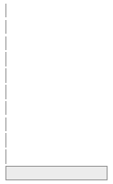

0  
(0.0%)

10

connectivity (new / upgrade)  
[character]

1. New  
2. Upgarde

1450 (40.0%)  
2179 (60.0%)

0  
(0.0%)

11

name of benefited habitations  
[character]

1. (Empty string)  
2. A. Emaliya Chechgra [ 775  
3. A.m Chhibbi [ 7817], Nisf  
4. Aadiwasi Basti [ 8016], B  
5. Aaggrey Purwa [ 8062], Ah  
6. Aahir Tola [ 8092], Babu  
7. Aam Gouriya [ 8249]  
8. Aama Kot [ 8274], Ahirawa  
9. Aan Purva [ 8444], Jailal  
10. Aandhariya Pur [ 8467], G  
[ 3483 others ]

137 ( 3.8%)  
1 ( 0.0%)  
1 ( 0.0%)  
1 ( 0.0%)  
1 ( 0.0%)  
1 ( 0.0%)  
1 ( 0.0%)  
1 ( 0.0%)  
1 ( 0.0%)  
1 ( 0.0%)  
3483 (96.0%)

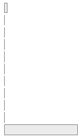

0  
(0.0%)

12

core-network road name  
[character]

1. (Empty string)  
2. G.t.road Km.110.70 To G.t  
3. Hathgaon pattishah Road K  
4. P.g.b.road Km.74.00 To P.  
5. Fatehpur (ch. 0.00 To 8.0  
6. Saidpur To Chiraiyakote  
7. G.t.road Ch Km.85.00 To G  
8. Ghazipur Saidraja Road (n  
9. Godaur To Sonwani  
10. J.a.c.j.j. road K.m.4.00  
[ 3292 others ]

10 ( 0.3%)  
8 ( 0.2%)  
8 ( 0.2%)  
8 ( 0.2%)  
7 ( 0.2%)  
7 ( 0.2%)  
6 ( 0.2%)  
6 ( 0.2%)  
6 ( 0.2%)  
6 ( 0.2%)  
3557 (98.0%)

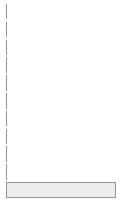

0  
(0.0%)

13

core-network habitation name  
[character]

1. (Empty string)  
2. Badsahi [ 64705] { 4673}  
3. Bai Bajar [ 72033] { 411}  
4. Laldaspur [ 617753] { 399  
5. A.k. Swad [ 7794] { 3817}  
6. Bhitaura [ 151824] { 3010  
7. Amauli [ 29306] { 6218} ,  
8. Baruin [ 108463] { 5717}  
9. Chak Khan Muhammad [ 1918  
10. Faridpur usraina [ 328487  
[ 3163 others ]

158 ( 4.4%)  
8 ( 0.2%)  
8 ( 0.2%)  
8 ( 0.2%)  
7 ( 0.2%)  
7 ( 0.2%)  
6 ( 0.2%)  
6 ( 0.2%)  
6 ( 0.2%)  
6 ( 0.2%)  
3409 (93.9%)

0  
(0.0%)

14

sanction cost  
[numeric]

Mean (sd) : 172.3 (148.9)  
min < med < max:  
10 < 116.1 < 1468.3  
IQR (CV) : 194.2 (0.9)

3420 distinct values

0  
(0.0%)

15

state cost  
[numeric]

Min : 0  
Mean : 0  
Max : 1.2

0.00 : 3628 (100.0%)  
1.15 : 1 ( 0.0%)

0  
(0.0%)

16

road length (kms)  
[numeric]

Mean (sd) : 4.6 (3.9)  
min < med < max:  
0.4 < 3.2 < 23  
IQR (CV) : 5.5 (0.9)

703 distinct values

0  
(0.0%)

17

bridge length (mtrs)  
[integer]

1 distinct value

0 : 3629 (100.0%)

0  
(0.0%)

18

road length completed till date  
[numeric]

Mean (sd) : 4.5 (3.9)  
min < med < max:  
0 < 3 < 22.9  
IQR (CV) : 5.6 (0.9)

874 distinct values

0  
(0.0%)

19

expenditure till date  
[numeric]

Mean (sd) : 162 (144.1)  
min < med < max:  
6.8 < 104.2 < 1334.9  
IQR (CV) : 187.9 (0.9)

3400 distinct values

0  
(0.0%)

20

stage of progress  
[character]

1. Completed  
2. Maintenance  
3. Sub-Grade Stage  
4. Subbase / GSB Stage  
5. Surface Course / BT Stage

521 (14.4%)  
3105 (85.6%)  
1 ( 0.0%)  
1 ( 0.0%)  
1 ( 0.0%)

0  
(0.0%)

21

collaboration  
[character]

1. Regular PMGSY  
2. World Bank (RRP-I)  
3. World Bank (RRP-II)

2021 (55.7%)  
145 ( 4.0%)  
1463 (40.3%)

0  
(0.0%)

22

contractor name  
[character]

1. MOHD UMAR KHAN  
2. M/s Maa Vindhyavasini Con  
3. M/s Sunil Gargh and compa  
4. M/s. RAM SANEHI AND SONS  
5. SR INFRA CONSTRUCTION PVT  
6. RCC DEVELOPERS PVT LTD  
7. M/S Durga Builders  
8. M/s Rakesh Pratap Singh C  
9. AKHILESH KUMAR PATHAK  
10. M/s. Divya Construction C  
[ 802 others ]

44 ( 1.2%)  
37 ( 1.0%)  
32 ( 0.9%)  
31 ( 0.9%)  
28 ( 0.8%)  
27 ( 0.7%)  
26 ( 0.7%)  
26 ( 0.7%)  
25 ( 0.7%)  
25 ( 0.7%)  
3328 (91.7%)

0  
(0.0%)

23

5 years maintenance cost due  
[numeric]

Mean (sd) : 8.4 (7.7)  
min < med < max:  
0 < 5.8 < 195.6  
IQR (CV) : 9.6 (0.9)

1210 distinct values

0  
(0.0%)

24

completion date  
[character]

1. Financial: 31-03-2010/ Ph  
2. Financial: 31-12-2015/ Ph  
3. Financial: 27-03-2015/ Ph  
4. Financial: 30-03-2010/ Ph  
5. Financial: 13-05-2016/ Ph  
6. Financial: 23-07-2012/ Ph  
7. Financial: 31-03-2010/ Ph  
8. Financial: 21-05-2015/ Ph  
9. Financial: 30-03-2010/ Ph  
10. Financial: 21-03-2015/ Ph  
[ 2577 others ]

19 ( 0.5%)  
18 ( 0.5%)  
13 ( 0.4%)  
11 ( 0.3%)  
10 ( 0.3%)  
10 ( 0.3%)  
10 ( 0.3%)  
9 ( 0.2%)  
9 ( 0.2%)  
8 ( 0.2%)  
3512 (96.8%)

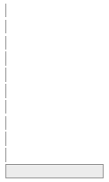

0  
(0.0%)

25

blocknew  
[character]

1. pisawan  
2. pahari  
3. barhpura  
4. chopan  
5. ramnagar  
6. binauli  
7. dingarpur  
8. pasgawan  
9. gola  
10. nawabganj  
[ 659 others ]

29 ( 0.8%)  
25 ( 0.7%)  
23 ( 0.6%)  
23 ( 0.6%)  
23 ( 0.6%)  
22 ( 0.6%)  
22 ( 0.6%)  
22 ( 0.6%)  
21 ( 0.6%)  
21 ( 0.6%)  
3398 (93.6%)

0  
(0.0%)

26

assemblynew  
[character]

1. maholi  
2. kundarki  
3. baghpat  
4. nanpara  
5. chhanbey  
6. sidhauli  
7. mohammdi  
8. milak  
9. marihan  
10. sevata  
[ 311 others ]

49 ( 1.4%)  
47 ( 1.3%)  
46 ( 1.3%)  
42 ( 1.2%)  
38 ( 1.0%)  
38 ( 1.0%)  
36 ( 1.0%)  
35 ( 1.0%)  
34 ( 0.9%)  
34 ( 0.9%)  
3230 (89.0%)

0  
(0.0%)

27

assemblynumber  
[numeric]

Mean (sd) : 208.1 (116.1)  
min < med < max:  
1 < 199 < 403  
IQR (CV) : 185 (0.6)

319 distinct values

0  
(0.0%)

28

loksabha  
[integer]

Min : 14  
Mean : 14.7  
Max : 15

14 : 1203 (33.1%)  
15 : 2426 (66.9%)

0  
(0.0%)

29

ac name  
[character]

1. MOHOLI  
2. KUNDARKI  
3. BAGHPAT  
4. NANAPARA  
5. CHHANBEY (SC)  
6. SIDHAULI (SC)  
7. MOHAMMDI  
8. MILAK (SC)  
9. MARIHAN  
10. SEVATA  
[ 309 others ]

49 ( 1.4%)  
47 ( 1.3%)  
46 ( 1.3%)  
42 ( 1.2%)  
38 ( 1.0%)  
38 ( 1.0%)  
36 ( 1.0%)  
35 ( 1.0%)  
34 ( 0.9%)  
34 ( 0.9%)  
3230 (89.0%)

0  
(0.0%)

30

ac no  
[numeric]

Mean (sd) : 208.1 (116.1)  
min < med < max:  
1 < 199 < 403  
IQR (CV) : 185 (0.6)

319 distinct values

0  
(0.0%)

31

districts  
[character]

1. Sitapur  
2. Hardoi  
3. Baharaich  
4. Mirzapur  
5. Moradabad  
6. Baghpat  
7. Kheri  
8. Sonbhadra  
9. Unnao  
10. Rampur  
[ 65 others ]

202 ( 5.6%)  
151 ( 4.2%)  
135 ( 3.7%)  
104 ( 2.9%)  
94 ( 2.6%)  
92 ( 2.5%)  
91 ( 2.5%)  
85 ( 2.3%)  
80 ( 2.2%)  
79 ( 2.2%)  
2516 (69.3%)

0  
(0.0%)

32

district code  
[numeric]

Mean (sd) : 9136.9 (3.3)  
min < med < max:  
9132 < 9138 < 9141  
IQR (CV) : 6 (0)

9132 : 63 (18.6%)  
9133 : 26 ( 7.7%)  
9134 : 32 ( 9.5%)  
9138 : 54 (16.0%)  
9139 : 92 (27.2%)  
9140 : 27 ( 8.0%)  
9141 : 44 (13.0%)

3291  
(90.7%)

33

pc name  
[character]

1. DHAURAHRA  
2. MISRIKH (SC)  
3. SHRAWASTI  
4. MIRZAPUR  
5. ROBERTSGANJ (SC)  
6. BAHRAICH (SC)  
7. BAGHPAT  
8. SAMBHAL  
9. UNNAO  
10. RAMPUR  
[ 68 others ]

133 ( 3.7%)  
111 ( 3.1%)  
107 ( 2.9%)  
104 ( 2.9%)  
102 ( 2.8%)  
98 ( 2.7%)  
97 ( 2.7%)  
85 ( 2.3%)  
80 ( 2.2%)  
79 ( 2.2%)  
2633 (72.6%)

0  
(0.0%)

34

constituency_no  
[numeric]

Mean (sd) : 41.6 (23)  
min < med < max:  
1 < 40 < 80  
IQR (CV) : 36 (0.6)

78 distinct values

0  
(0.0%)

35

sanctionedcostnew  
[numeric]

Mean (sd) : 168.1 (135.3)  
min < med < max:  
10 < 116.1 < 500  
IQR (CV) : 194.2 (0.8)

3294 distinct values

0  
(0.0%)

36

year_ac  
[numeric]

Min : 2007  
Mean : 2009.4  
Max : 2012

2007 : 1869 (51.5%)  
2012 : 1760 (48.5%)

0  
(0.0%)

## 3.2 total stats

PMGSY across years

| Loksabha Term | Number of projects | Length coverd (Kms) | Total sanctioned amount (Lakhs) |
| --- | --- | --- | --- |
| Family | 844 | 3116 | 119361 |
| Non-family | 1582 | 6145 | 234752 |

## 3.3 Constituency level avg.

PMGSY summary stats wrt constituency type

| Constituency Type | Average number of projects | Average length per project | Average length over all |
| --- | --- | --- | --- |
| Family | 30.1 | 3.7 | 111.3 |
| Non-family | 31.6 | 3.9 | 122.9 |

## 3.4 Contractors

PMGSY average number of contractors and amount sanctioned wrt constituency type

| Type of constituency | Average number of unique contractors | AAvergae amount sanctioned to a unique contractor (Lakhs) |
| --- | --- | --- |
| Family | 16 | 483 |
| Non-family | 17 | 529 |

# 4 NREGA

**Variable summary**

Workdays - total days worked under NREGS

– Coded as: log(Workdays + 1)

Worked - number of individuals who worked under NREGS

– Coded as: log(Worked + 1)

Deposits - sum of disbursements to laborers’ bank and post office accounts

– Coded as: log(Bank Deposits + Post office Deposits + 1)

## 4.1 Summary table

| No | Variable | Stats / Values | Freqs (% of Valid) | Graph | Missing |
| --- | --- | --- | --- | --- | --- |
| 1 | constituency_no [numeric] | Mean (sd) : 45.7 (22.5) min < med < max: 1 < 48 < 80 IQR (CV) : 38 (0.5) | 78 distinct values |  | 0 (0.0%) |
| 2 | worked [numeric] | Mean (sd) : 4.6 (0.8) min < med < max: 0 < 4.6 < 7.7 IQR (CV) : 0.8 (0.2) | 660 distinct values |  | 0 (0.0%) |
| 3 | workdays [numeric] | Mean (sd) : 7.8 (1.1) min < med < max: 0 < 7.9 < 11.5 IQR (CV) : 0.9 (0.1) | 9643 distinct values |  | 0 (0.0%) |
| 4 | workdays_jc [numeric] | Mean (sd) : 2.4 (0.6) min < med < max: 0 < 2.5 < 4.4 IQR (CV) : 0.8 (0.3) | 43971 distinct values |  | 39 (0.0%) |
| 5 | disbursed_all [numeric] | Mean (sd) : 12.5 (1.5) min < med < max: 0 < 12.7 < 16.4 IQR (CV) : 1 (0.1) | 19719 distinct values |  | 0 (0.0%) |
| 6 | ratio [numeric] | Mean (sd) : 0.8 (0.2) min < med < max: 0 < 0.8 < 6.2 IQR (CV) : 0.1 (0.2) | 41784 distinct values |  | 904 (1.1%) |

## 4.2 total stats

Summary of NREGA

| Year | Total number of projects | Total days | Average days per project | Average number of projects per constituency | Average days per constituency |
| --- | --- | --- | --- | --- | --- |
| 2009 | 85333 | 667898.9 | 7.8 | 1094 | 8562.8 |

## 4.3 Constituency avg.

NREGA summary stats wrt constituency type

| Caste group | Average number of projects | Average days | Average number of poeple | Average money disbursed |
| --- | --- | --- | --- | --- |
| Family | 1057.2 | 8258.4 | 4792.8 | 13169.7 |
| Non-family | 1114.6 | 8733.3 | 5125.2 | 13975.3 |

# 5 Pol consequences

## 5.1 UP CV

This is carried out using AE election booth level data from 2007, 2012, 2017 UP elections

### 5.1.1 CV density graphs

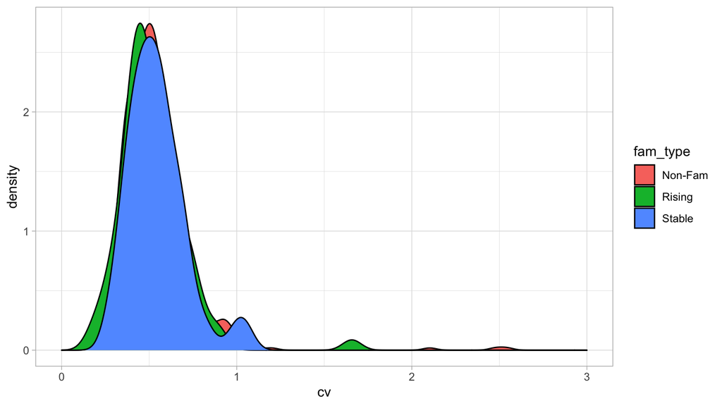

### 5.1.2 Linear regression

|  | *Dependent variable:* |
| --- | --- |
|  | cv |
| dynast | 0.024 |
|  | (0.069) |
| margin_percentage | 0.029 |
|  | (0.031) |
| vote_share_percentage | -0.075 |
|  | (0.064) |
| enop | -0.430 |
|  | (0.469) |
| incumbent | 0.064 |
|  | (0.110) |
| log(electors) | 0.831 |
|  | (2.689) |
| turnout_percentage | 0.056* |
|  | (0.032) |
| Fixed effects | Year and Constituency |
| Clustered SE | Constituency |
| Observations | 744 |
| R<sup>2</sup> | 0.576 |
| Adjusted R<sup>2</sup> | 0.071 |
| Residual Std. Error | 1.026 (df = 339) |
| *Note:* | p<0.1; p<0.05; p<0.01 |

### 5.1.3 close elections [5 PC] break up

| dynast | count |
| --- | --- |
| 0 | 56 |
| 1 | 28 |

### 5.1.4 rdd graph

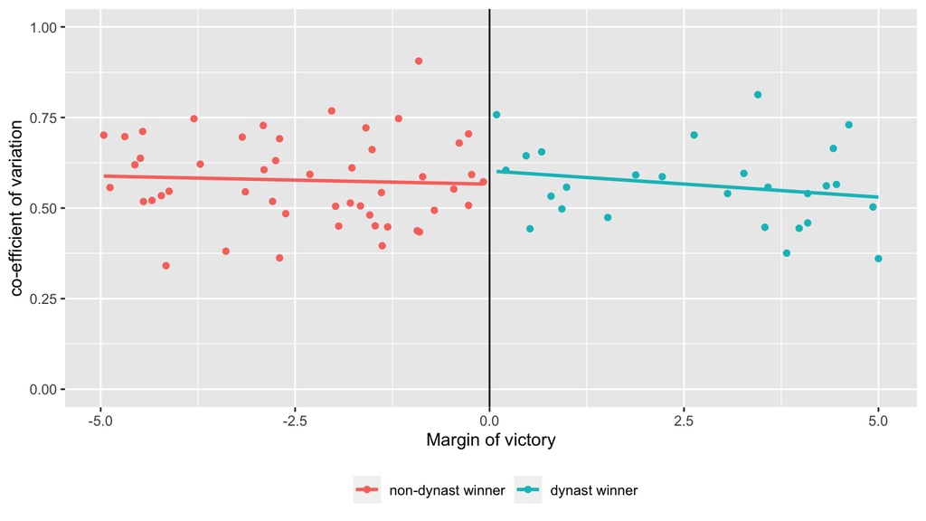

### 5.1.5 RDD model

|  | *Dependent variable:* |
| --- | --- |
|  | cv |
| Stable | 0.003 |
|  | (0.030) |
| Constatnt | 0.577*** |
|  | (0.018) |
| Observations | 77 |
| R<sup>2</sup> | 0.0002 |
| Adjusted R<sup>2</sup> | -0.013 |
| Residual Std. Error | 0.128 (df = 75) |
| *Note:* | p<0.1; p<0.05; p<0.01 |